# Stars 1

Walter Humberto Subiza Piña

04/12/2020

## Presentando “stars”

En 2018, el tratamiento y manipulación de datos georreferenciados de tipo vectorial em *R* fue revolucionado con el lanzamiento de **Pebesma E (2018) Simple features for R: standardized support for spatial vector data. R J 10(1):439–446** y la consecuente biblioteca **sf** que implementaba los conceptos introducidos.

De forma concisa se puede decir que la nueva propuesta, era que los datos espaciales vectoriales pueden ser representados por un dataframe, en el cual se incluye una nueva columna de tipo *lista*, que contiene la geometria del objeto a representar.

Los objetos creados son de la clase *sf* o *simple features* (ver documentación de la biblioteca **sf**). Al tratar los objetos espaciales como dataframe, sus columnas o atributos, son facilmente manipulados y extraídos sin perder el georreferenciamiento en el proceso.

Los archivos o datos de tipo raster por otro lado no estaban todavia contemplados, por lo que el análisis espacial en *R* se completaba con la biblioteca **raster**.

Asi fué hecho por ejemplo, el curso **Introdução ao Análise Espacial** https://github.com/HumbertoSubiza/Intro_analise_espacial_R (en idioma portugués), ofrecido en el Instituto Brasileiro de Geografia e Estatística en Rio de Janeiro, Brasil en 2019.

Sin embargo, el concepto de tener una biblioteca mas flexible y completa para el tratamiento de todo tipo de dato espacial continuaba a ser elaborada y así surge la biblioteca **stars** - Spatiotemporal Arrays, Raster and Vector Data Cubes

Esta biblioteca introduce otro concepto nuevo en *R*, el de *datacubes array*, que podria ser traducido como arreglo cúbico de datos (una sugerencia) y donde la altura del cubo viene dada por múltiples dimensiones.

Asi, el menor archivo raster tiene dos dimensiones espaciales representando la localización por ejemplo y un atributo que es el tipo de dato de la capa (layer). En la figura a seguir se representa un arreglo cúbico de cinco dimensiones.

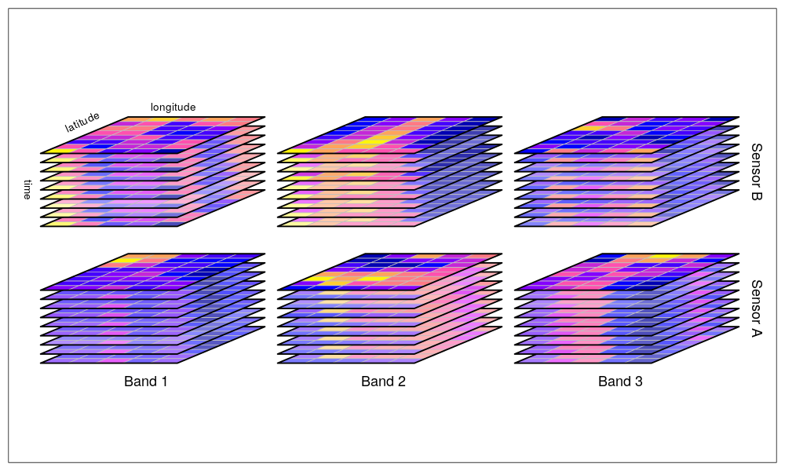

**Cinco dimensiones: longitud, latitud, tiempo, banda y sensor**

En el caso de archivos de tipo vectorial, éstos tienen 1 dimensión, dada por una lista con la geometria del objeto y pueden tener varios atributos.

Cuando la biblioteca **stars** es cargada en el ambiente *R*, trae consigo 2 bibliotecas auxiliares ( *abind* e *sf*) y se conecta con 3 más, que son:

1. **abind**, para tratamiento de arreglos multi-dimensionales;
2. **sf**, biblioteca para objetos georreferenciados del tipo vectorial;
3. GEOS- *rgeos*, manipulación de la geometria de los elementos georreferenciados;
4. GDAL- *rgadal*, para transformación de formatos vectoriales y raster;
5. PROJ- *proj4*, interfase para transformación de sistemas de coordenadas geográficas en sistema de coordenadas proyectadas.

```r
library(stars)
```

Los objetos creados por esta nueva biblioteca pertenecen a una nueva clase, denominada **stars** y que al dia de hoy tiene los siguientes métodos disponibles:

```r
methods(class = "stars")
```

```
##  [1] $<-               [                 [<-               adrop
##  [5] aggregate         aperm             as.data.frame     c
##  [9] coerce            contour           cut               dim
## [13] dimnames          dimnames<-        droplevels        filter
## [17] image             initialize        is.na             Math
## [21] merge             Ops               plot              predict
## [25] print             show              slotsFromS3       split
## [29] st_apply          st_area           st_as_sf          st_as_sfc
## [33] st_as_stars       st_bbox           st_coordinates    st_crop
## [37] st_crs            st_crs<-          st_dimensions     st_dimensions<-
## [41] st_extract        st_geometry       st_interpolate_aw st_intersects
## [45] st_join           st_mosaic         st_normalize      st_redimension
## [49] st_sample         st_transform      st_transform_proj write_stars
## see '?methods' for accessing help and source code
```

### 2. Recordando arreglos (arrays)

Antes de continuar, es útil recordar el concepto y manejo de arreglos en *R*.

**Arreglos son objetos con una estructura que permite almacenar datos multi-dimensionales.**

Como ejemplo, matrices y dataframes pueden contener líneas y columnas de datos, la diferencia con arreglos es que éste puede tener mas de 1 dimensión, de ahi la visualización como cubos o capas superpuestas. Como limitación los datos contenidos en cada dimensión deben ser del mismo tipo

Veamos algunos ejemplos. Creamos un arreglo de 4 x 4 con tres dimensiones, a partir de dos vectores numéricos.

```r
vector1 =  c (1, 2, 3,4) # primero vector con 4 números
vector2 =  c (5, 6, 7, 8, 9, 10, 11, 12) # segundo vector con 8 números
col.nombres <- c("col1","col2","col3","col4")
lin.nombres <- c("lin1","lin2","lin3","lin4")
matriz.nombres <- c("M1","M2","M3")
cubo = array (c(vector1, vector2), # creación del arreglo
              dim = c (4, 4, 3),# determinando el tamaño y dimensiones
              dimnames = list(lin.nombres, col.nombres, matriz.nombres))

cubo                                # visualización
```

```
## , , M1
##
##      col1 col2 col3 col4
## lin1    1    5    9    1
## lin2    2    6   10    2
## lin3    3    7   11    3
## lin4    4    8   12    4
##
## , , M2
##
##      col1 col2 col3 col4
## lin1    5    9    1    5
## lin2    6   10    2    6
## lin3    7   11    3    7
## lin4    8   12    4    8
##
## , , M3
##
##      col1 col2 col3 col4
## lin1    9    1    5    9
## lin2   10    2    6   10
## lin3   11    3    7   11
## lin4   12    4    8   12
```

Vemos en la visualización, la notacion de arreglos y tres capas llamadas de M1, M2 y M3. El objeto creado es solamente de la clase *array*. La extracción de datos usando el operador “[” es simple, siguiendo el orden linea, columna, dimensión.

```r
(M2 <- cubo[ , ,2]) # segunda capa o dimensión
```

```
##      col1 col2 col3 col4
## lin1    5    9    1    5
## lin2    6   10    2    6
## lin3    7   11    3    7
## lin4    8   12    4    8
```

```r
(M3_sub <- cubo[1:2, 2:4, 3]) # lineas 1 y 2, columnas 2 a 4 de la tercera dimensión
```

```
##      col2 col3 col4
## lin1    1    5    9
## lin2    2    6   10
```

Veremos mas adelante otras formas de extrair datos, usando funciones específicas de la biblioteca **stars**, que poseem pequeñas diferencias con las presentadas.

La biblioteca maneja tambien datos vectoriales, del tipo punto o poligono.

La conversion entre formato raster y vector es posible usando funciones especificas que veremos mas adelante.

Los datos vectoriales son tratados como *simple features* y todas las funciones del ambiente **sf** están disponibles para su manipulacion.

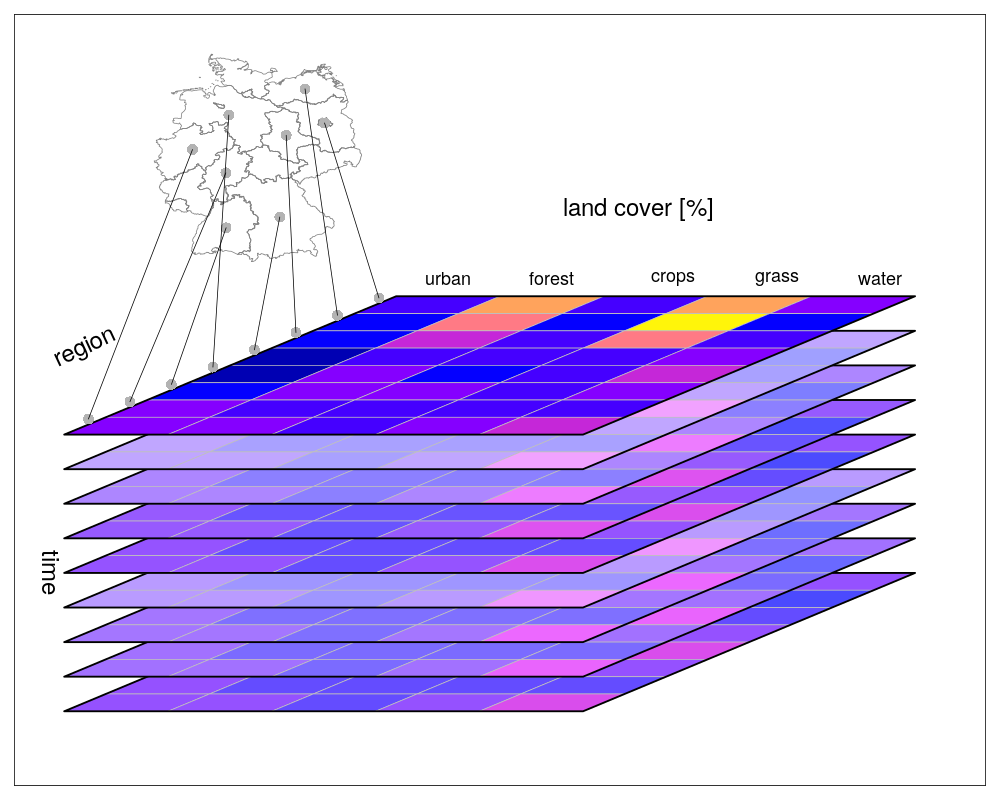

Datos vectoriales en stars

### Lectura de datos

Un archivo raster puede ser leído de un directorio externo al ambiente usando la función *read_stars()*, en donde ser requiere un único argumento del tipo texto, indicando el camino hasta él, o puede ser convertido al formato **stars**, si ya está dentro de las variables de ambiente a través de la función *st_as_stars()*.

La biblioteca permite trabajar con dados en mallas regular o irregulamente espaciadas, así como con proyecciones cartesianas o curvilíneas. Durante la lectura e importación del archivo (o parte de él), los valores de las bandas importadas muchas vezes UINT8 o UINT16, son convertidos a valores numéricos de doble precisión y si necesario, reconvertidos. Todos los datos importados en la lectura se almacenan en una única estructura de arreglo **stars**.

Para simplificar vamos leer un archivo raster de ejemplo que la propia biblioteca **stars** incluye. El archivo es una imagem Landsat 7 ETM, con 6 bandas, azul, verde, rojo (BGR) y 3 más de infrarrojo, emn formato Geotiff. La importación hará uso de la biblioteca GDAL.

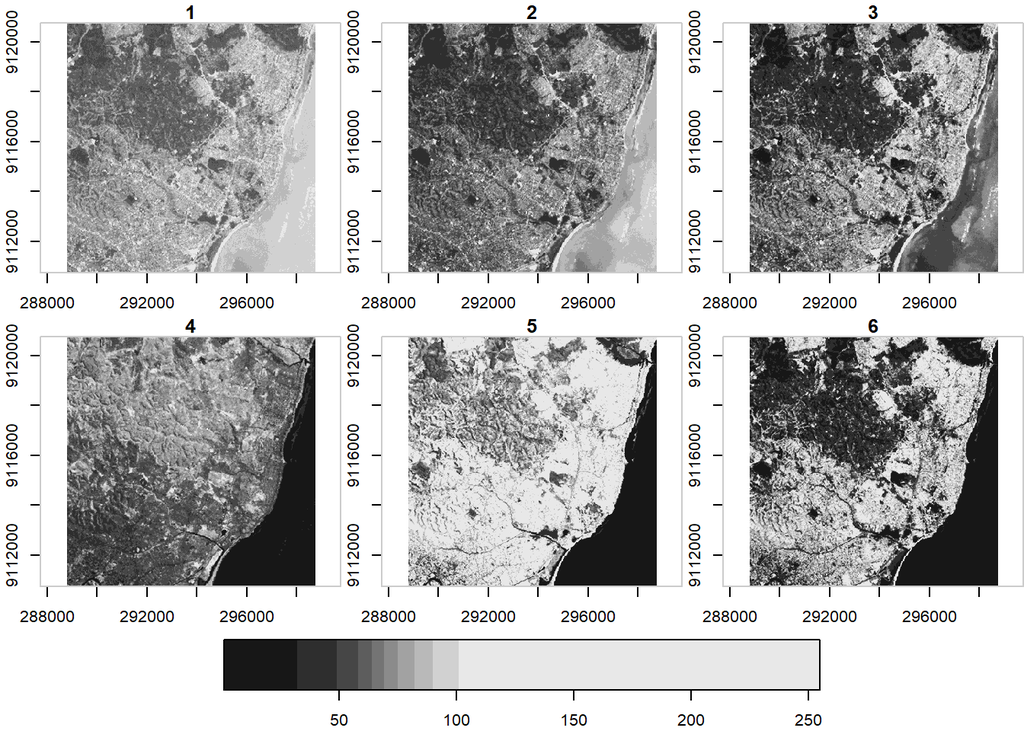

```r
tif = system.file("tif/L7_ETMs.tif", package = "stars")# creacion del camino del archivo como objeto texto

img = read_stars(tif) # lectura del archivo

plot(img, axes = T)
```

### 3. Explorando el objeto

Veamos las características del objeto creado.

```r
img
```

```
## stars object with 3 dimensions and 1 attribute
## attribute(s):
##   L7_ETMs.tif
##  Min.   :  1.00
##  1st Qu.: 54.00
##  Median : 69.00
##  Mean   : 68.91
##  3rd Qu.: 86.00
##  Max.   :255.00
## dimension(s):
##      from  to  offset delta                       refsys point values
## x       1 349  288776  28.5 UTM Zone 25, Southern Hem... FALSE   NULL [x]
## y       1 352 9120761 -28.5 UTM Zone 25, Southern Hem... FALSE   NULL [y]
## band    1   6      NA    NA                           NA    NA   NULL
```

Vemos que el objeto creado es de la clase **stars** y tiene 3 dimensiones, ( *x*, *y* e *band*) y 1 atributo que son los valores de cada banda. A continuación presenta las estadísticas de los valores del atributo para la totalidad del archivo/atributo.

Por último muestra los componentes de cada dimensión, siendo:

| campo | significado |
| --- | --- |
| from | origen del indice (i = 1) |
| to | indice final (dim(x)[i]) |
| offset | valor inicial del pixel (si objeto regular) |
| delta | tamaño del intervalo de pixel o célula, (si objeto regular) |
| refsys | sistema geodésico de referencia en formato proj4 |
| point | valor lógico; las células son puntos (T) o intervalos (F) |
| values | secuencia de valores (ex. geometries),se irregular |

En el caso específico de la imagen importada la cantidad de células en la dimension *x* es de 349 y en la dimensión *y* de 352, comenzando con los valores de 288776 para el eje *x* y de 9120761 para *y*. El sistema de referencia es UTM zona 25S y los intervalos entre cada célula (delta) de 28,5 m y -28,5 m respectivamente. La imagen corresponde a un raster (point = F) del área de Recife, Brasil.

La referencia espacial para los indices está dada por la esquina superior izquierda de cada célula o pixel, siendo la primera célula aquella localizada en la esquina superior izquierda del mosaico. El índice se cuenta de izquierda a derecha y de la parte superior a la inferior, si deseamos valores al centro de la célula precisamos agregar la mitad del intervalo o delta al valor a calcular.

La fórmula para el cálculo del valor de cada célula en una determinada dimensión (espacial o temporal) seria
$$v = offset + (i−1) × delta$$
.

De esta forma el valor para la célula *v(15, 20)*, en las dimensiones *x* e *y* seria:
$$v_{x_{15}} = 288776 + (15-1)~ X~ 28.5 = 289175$$
y
$$v_{y_{20}} = 9120761 + (20-1)~ X~ -28.5 = 9120220$$
.

Para valores referidos al centro de la célula, el valor absoluto del delta debe ser aumentado em $14.3$.

Si se quiere extrair un subconjunto de datos de una área específica, podemos usar la notación de arreglos con cuatro valores de la seguiente forma: el primer argumento en el paréntesis recto es el atributo escogido, en este caso tenemos solamente un atributo. El segundo valor se refiere a la segunda dimensión, que es *x*, el tercer valor se refiere a la tercera dimensión *y* y por último, el cuarto valor se refiere a la capa o capas a extrair. Asi para extrair los valores de *x* del 1 al 10 e *y* del 20 al 30 de las bandas 3 y 4, colocamos el siguiente paréntesis [1, 1:10, 20:30, 3:4]. En la práctica:

```r
dim(img[[1]]) # dimensiones del objeto
```

```
##    x    y band
##  349  352    6
```

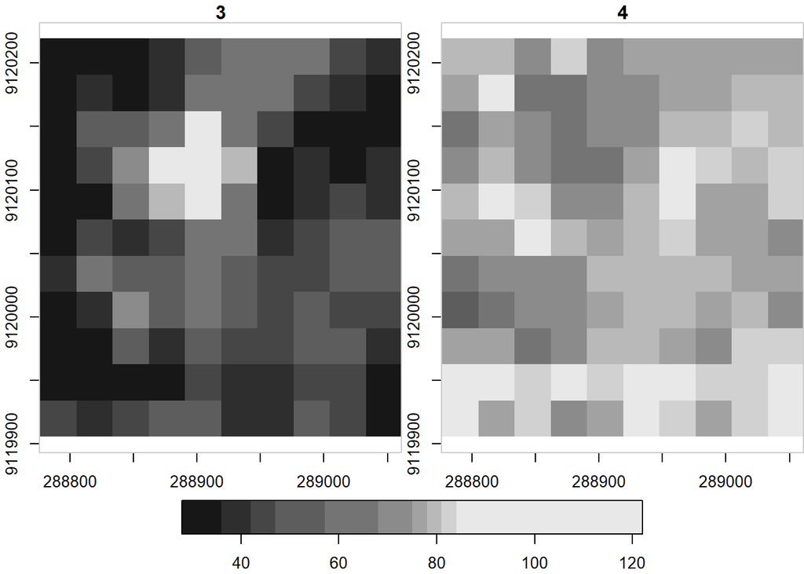

```r
plot(img[1, 1:10, 20:30, 3:4], axes = T) # Extracción y visualización
```

### 4. Lectura de archivo vectorial tipo ESRI por la biblioteca **sf**.

Los objetos del tipo vectorial pueden importarse a través de la biblioteca **sf** o pueden crearse usando funciones de la propia biblioteca **stars**. Primero vamos importar un archivo de la misma área de la imagen anterior, que representa los límites del municipio de Olinda, Pernambuco, Brasil. El mismo fue obtenido de la página oficial del Instituto Brasileiro de Geografia e Estatística (IBGE) https://www.ibge.gov.br/geociencias/organizacao-do-territorio/malhas-territoriais/.

```r
olinda <- read_sf("C:/Users/Walter Pina/Documents/Github/spatial_stars/datos/olinda.shp") # lectura
class(olinda)  # clase
```

```
## [1] "sf"         "tbl_df"     "tbl"        "data.frame"
```

```r
olinda         # características del objeto importado
```

```
## Simple feature collection with 1 feature and 5 fields
## geometry type:  POLYGON
## dimension:      XY
## bbox:           xmin: 288712.2 ymin: 9110320 xmax: 298506.6 ymax: 9120257
## projected CRS:  WGS 84 / UTM zone 25S
## # A tibble: 1 x 6
##     gid cd_mun  nm_mun sigla_uf area_km2                                geometry
##   <dbl> <chr>   <chr>  <chr>       <dbl>                           <POLYGON [m]>
## 1  1576 2609600 Olinda PE           41.3 ((295947.2 9118824, 295914.2 9118829, ~
```

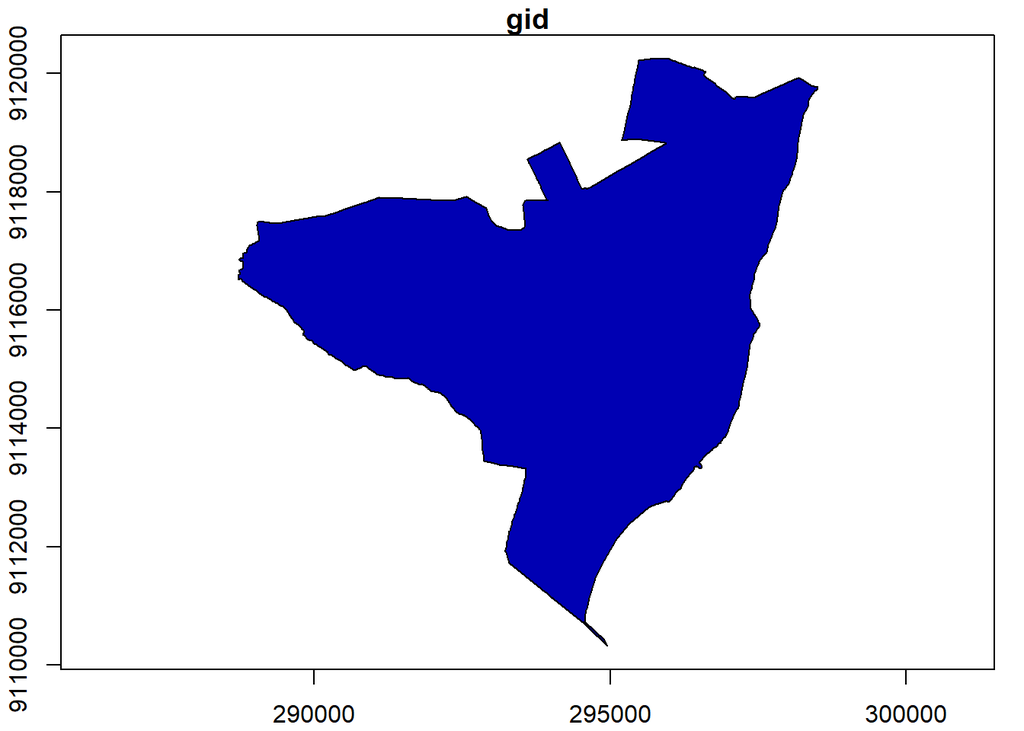

```r
plot(olinda["gid"], axes = T) # visualización como objeto sf
```

El objeto importado es del tipo polígono con 5 atributos, en projección UTM zona 25S del sistema de referencia geodésico WGS84. La clase es, entre otras, **sf** y **dataframe**. Los atributos son presentados como una tabla con los valores de cada atributo y la columna final con la geometria del objeto.

Transformación del objeto en clase **stars**, características y visualización.

```r
olinda_st <- st_as_stars(olinda)
class(olinda_st)
```

```
## [1] "stars"
```

```r
olinda_st
```

```
## stars object with 1 dimensions and 5 attributes
## attribute(s):
##       gid         cd_mun             nm_mun            sigla_uf
##  Min.   :1576   Length:1           Length:1           Length:1
##  1st Qu.:1576   Class :character   Class :character   Class :character
##  Median :1576   Mode  :character   Mode  :character   Mode  :character
##  Mean   :1576
##  3rd Qu.:1576
##  Max.   :1576
##    area_km2
##  Min.   :41.3
##  1st Qu.:41.3
##  Median :41.3
##  Mean   :41.3
##  3rd Qu.:41.3
##  Max.   :41.3
## dimension(s):
##          from to offset delta                       refsys point
## geometry    1  1     NA    NA +proj=utm +zone=25 +south... FALSE
##                                  values
## geometry POLYGON ((295947 9118824, 2...
```

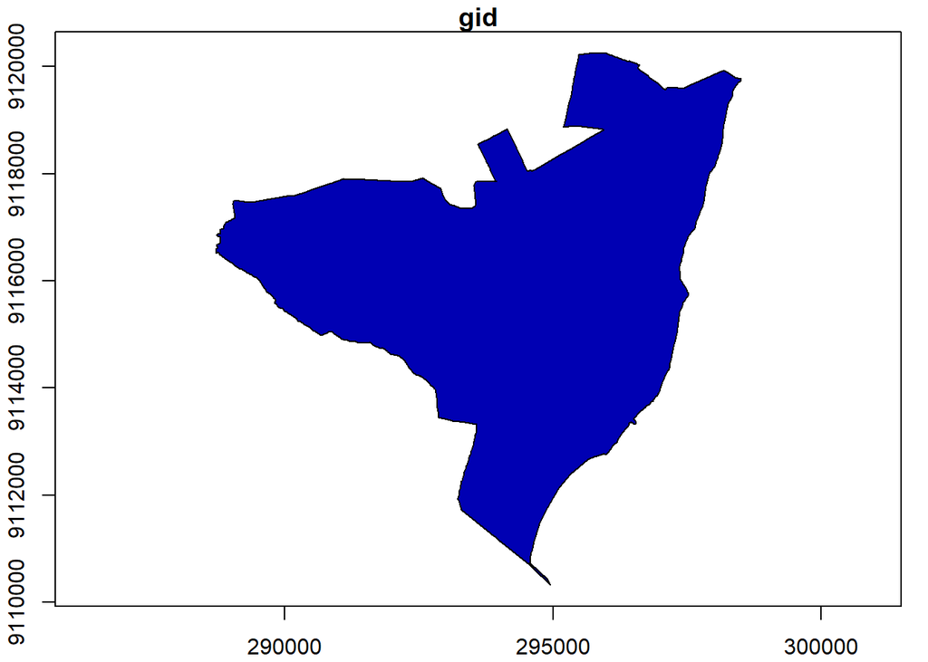

```r
plot(olinda_st["gid"], axes = T)
```

El objeto es del tipo **stars**, con apenas 1 dimensión (la geometria del objeto) y 5 atributos, siendo éstos presentados en resumen estadístico, dependiendo del tipo de atributo. La visualización es semejante a la anterior, pudiendo colocar en el comando *plot()*, el nombre o el número del atributo deseado.

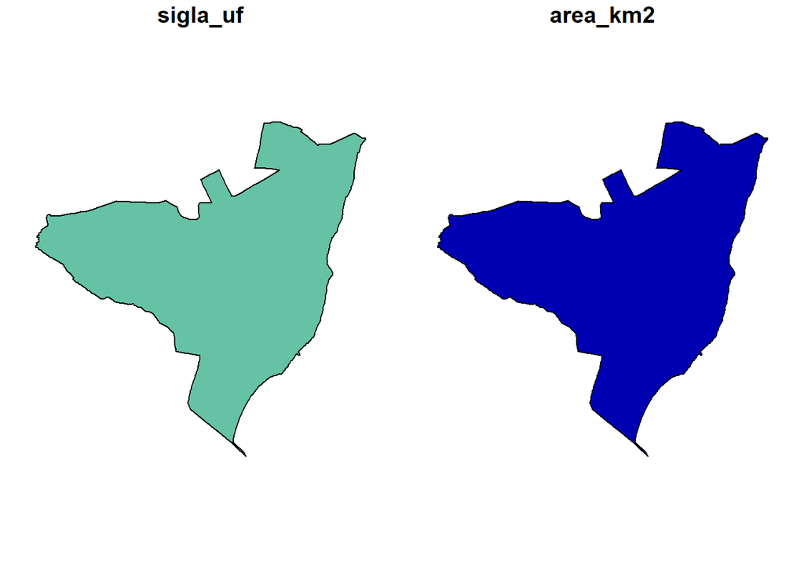

```r
plot(olinda_st[4:5])
```

### 5. Grabación de objetos **stars**

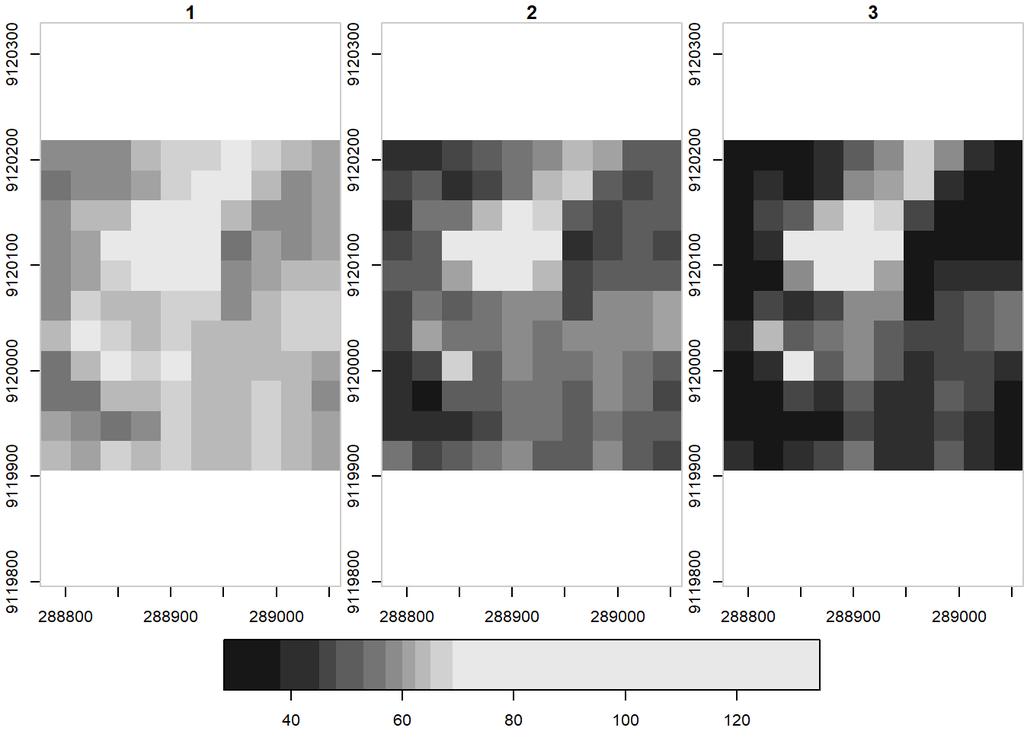

```r
write_stars(adrop(img[1, 1:10, 20:30, 1:3]), "stars1.tif")
tif <- c("stars1.tif")
stars1 <- read_stars(tif)
plot(stars1, axes = T)
```

### 6. Resumen y continuación

Vimos en esta introducción el nuevo concepto de *arreglo cúbico de datos espacio-temporales* dado por la biblioteca **stars**, lectura y análisis de los objetos creados y grabación de éstos.

Observese que los datos de tipo vectorial, son tratados por la biblioteca **sf**, cargada junto con la biblioteca **stars**. Las dos bibliotecas usadas en forma conjunta constituyen una poderosa herramienta para el tratamiento de este tipo de datos.

En el próximo documento veremos en forma mas detallada el manejo y tratamiento de los objetos **stars**, incluindo su interacción con datos vectoriales.

### Referencias

stars: Spatiotemporal Arrays, Raster and Vector Data Cubes en:

https://r-spatial.github.io/stars/index.html

https://github.com/r-spatial/stars/

Pebesma, E., 2018. Simple Features for R: Standardized Support for Spatial Vector Data. The R Journal 10 (1), 439-446, https://doi.org/10.32614/RJ-2018-009 https://r-spatial.github.io/sf/

Versión 1 de 2020-12-04 - Año Covid-19